# Covariance in multilevel models

### Estimation with `brms`

We can estimate an (almost) identical model using the `brm()` function from the `brms` package.

The main argument to `brm` is the model formula. The notation is similar to the standard R notation for linear regressions using `lm()`, but with extra components to specify grouping. In this case, `(1+age_s|teacher_id)` tells the moddel to use a random coefficient for the intercept (`1`) and age (`age_s`), and to have them grouped by `teacher_id`. Note that with `brm` we do not need to deal with re-indexing or removing missing values. All of that happens under the hood.

The other argument to pay attention to is the `prior` argument. `brm` has special ways to specify priors, and picks (usually) reasonable default priors for any that are left unspecified.

```r
t0 <- Sys.time()
fit_brm <- brm(
    formula=reading_score ~ age_s + (1+age_s|teacher_id),
    prior=c(
        set_prior("normal(500,100)",class="Intercept"),
        set_prior("normal(0,20)",class='b'),
        set_prior('lkj(2)',class='cor')
    ),
    data=d,chains=4,cores=4,
    control=list(adapt_delta=.999)
)
t1 <- Sys.time()
```

```r
t1-t0 # much faster!
```

```
Time difference of 1.430487 mins
```

```r
summary(fit_brm)
```

```
 Family: gaussian
  Links: mu = identity; sigma = identity
Formula: reading_score ~ age_s + (1 + age_s | teacher_id)
   Data: d (Number of observations: 1266)
Samples: 4 chains, each with iter = 2000; warmup = 1000; thin = 1;
         total post-warmup samples = 4000

Group-Level Effects:
~teacher_id (Number of levels: 329)
                     Estimate Est.Error l-95% CI u-95% CI Eff.Sample Rhat
sd(Intercept)           27.03      2.02    23.22    31.00       1632 1.00
sd(age_s)                3.11      1.98     0.16     7.45       1862 1.00
cor(Intercept,age_s)    -0.36      0.37    -0.89     0.52       3593 1.00

Population-Level Effects:
          Estimate Est.Error l-95% CI u-95% CI Eff.Sample Rhat
Intercept   521.88      2.07   517.80   525.85       3160 1.00
age_s        -6.88      1.54    -9.94    -3.91       5274 1.00

Family Specific Parameters:
      Estimate Est.Error l-95% CI u-95% CI Eff.Sample Rhat
sigma    46.56      1.04    44.54    48.68       3602 1.00

Samples were drawn using sampling(NUTS). For each parameter, Eff.Sample
is a crude measure of effective sample size, and Rhat is the potential
scale reduction factor on split chains (at convergence, Rhat = 1).
```

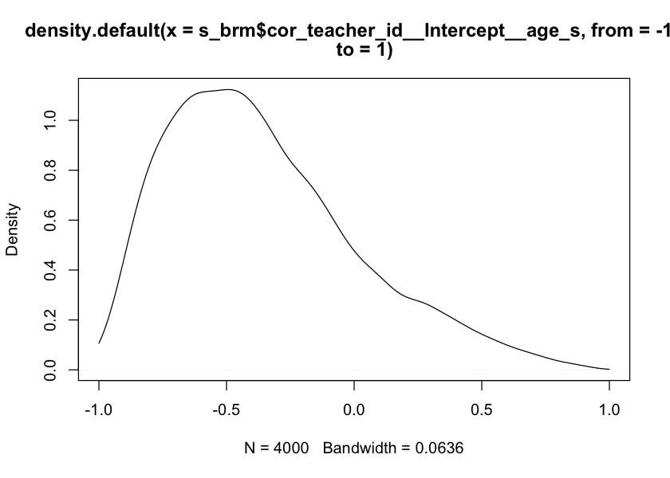

```r
s_brm <- posterior_samples(fit_brm)
plot(density(s_brm$cor_teacher_id__Intercept__age_s,from=-1,to=1))
```

```r
# the priors we did not specify were set automatically by brm
prior_summary(fit_brm)
```

| prior | class | coef | group | resp | dpar | nlpar | bound |
| --- | --- | --- | --- | --- | --- | --- | --- |
| normal(0,20) | b |  |  |  |  |  |  |
|  | b | age_s |  |  |  |  |  |
| normal(500,100) | Intercept |  |  |  |  |  |  |
| lkj_corr_cholesky(2) | L |  |  |  |  |  |  |
|  | L |  | teacher_id |  |  |  |  |
| student_t(3, 0, 58) | sd |  |  |  |  |  |  |
|  | sd |  | teacher_id |  |  |  |  |
|  | sd | age_s | teacher_id |  |  |  |  |
|  | sd | Intercept | teacher_id |  |  |  |  |
| student_t(3, 0, 58) | sigma |  |  |  |  |  |  |